# Self-Driving Car Engineer Nanodegree

## Project: Build a Traffic Sign Recognition Classifier

In this notebook, a template is provided for you to implement your functionality in stages which is required to successfully complete this project. If additional code is required that cannot be included in the notebook, be sure that the Python code is successfully imported and included in your submission, if necessary. Sections that begin with **'Implementation'** in the header indicate where you should begin your implementation for your project. Note that some sections of implementation are optional, and will be marked with **'Optional'** in the header.

In addition to implementing code, there will be questions that you must answer which relate to the project and your implementation. Each section where you will answer a question is preceded by a **'Question'** header. Carefully read each question and provide thorough answers in the following text boxes that begin with **'Answer:'**. Your project submission will be evaluated based on your answers to each of the questions and the implementation you provide.

> **Note:** Code and Markdown cells can be executed using the **Shift + Enter** keyboard shortcut. In addition, Markdown cells can be edited by typically double-clicking the cell to enter edit mode.

## Step 0: Load The Data

```python
# Load pickled data
import pickle
from sklearn.model_selection import train_test_split
from sklearn.utils import shuffle
import numpy as np

training_file = "./traffic-signs-data/train.p"
testing_file = "./traffic-signs-data/test.p"

with open(training_file, mode='rb') as f:
    train = pickle.load(f)
with open(testing_file, mode='rb') as f:
    test = pickle.load(f)

X_train, y_train = train['features'], train['labels']
X_test, y_test = test['features'], test['labels']

assert(len(X_train) == len(y_train))
assert(len(X_test) == len(y_test))

print()
print("Image Shape: {}".format(X_train[0].shape))
print()
print("Training Set:   {} samples".format(len(X_train)))
print("Test Set:       {} samples".format(len(X_test)))
```

```
Image Shape: (32, 32, 3)

Training Set:   39209 samples
Test Set:       12630 samples
```

## Step 1: Dataset Summary & Exploration

The pickled data is a dictionary with 4 key/value pairs:

- `'features'` is a 4D array containing raw pixel data of the traffic sign images, (num examples, width, height, channels).
- `'labels'` is a 2D array containing the label/class id of the traffic sign. The file `signnames.csv` contains id -> name mappings for each id.
- `'sizes'` is a list containing tuples, (width, height) representing the the original width and height the image.
- `'coords'` is a list containing tuples, (x1, y1, x2, y2) representing coordinates of a bounding box around the sign in the image. **THESE COORDINATES ASSUME THE ORIGINAL IMAGE. THE PICKLED DATA CONTAINS RESIZED VERSIONS (32 by 32) OF THESE IMAGES**

Complete the basic data summary below.

```python
### Replace each question mark with the appropriate value.

# TODO: Number of training examples
n_train = len(X_train)

# TODO: Number of testing examples.
n_test = len(X_test)

# TODO: What's the shape of an traffic sign image?
image_shape = X_train.shape

# TODO: How many unique classes/labels there are in the dataset.
n_classes = len(set(y_train).union(set(y_test)))

print("Number of training examples =", n_train)
print("Number of testing examples =", n_test)
print("Image data shape = {:.0f} x {:.0f}".format(float(image_shape[1]), float(image_shape[2])))
print("Number of classes =", n_classes)
```

```
Number of training examples = 39209
Number of testing examples = 12630
Image data shape = 32 x 32
Number of classes = 43
```

Visualize the German Traffic Signs Dataset using the pickled file(s). This is open ended, suggestions include: plotting traffic sign images, plotting the count of each sign, etc.

The [Matplotlib](http://matplotlib.org/) [examples](http://matplotlib.org/examples/index.html) and [gallery](http://matplotlib.org/gallery.html) pages are a great resource for doing visualizations in Python.

**NOTE:** It's recommended you start with something simple first. If you wish to do more, come back to it after you've completed the rest of the sections.

We start by looking at a couple of images:

[figure not shown]

```python
### Data exploration visualization goes here.
### Feel free to use as many code cells as needed.
import matplotlib.pyplot as plt
import matplotlib.image as mpimg

# Visualizations will be shown in the notebook.
%matplotlib inline
plt.imshow(X_train[0])
```

The above example shows one difficulty: as humans, we know that are actually two traffic signs and as drivers we also know *which* two traffic signs these are. If we insist that the algorithm can only output *one* traffic sign, this can actually be problematic: say, it classifies the above picture as pedestrian crossing, then it would actually be right, but it would reduce the accuracy.

[figure not shown]

```python
plt.imshow(X_train[300])
```

[figure not shown]

```python
plt.imshow(X_train[24000])
```

We should also be able to recognize traffic signs in darker light conditions.

```
<Container object of 43 artists>
```

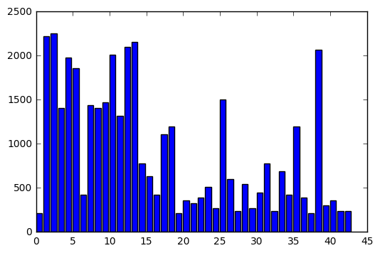

```python
import pandas as pd
import numpy as np
%matplotlib inline
y_train_pd = pd.DataFrame(y_train, columns = ['Classid'])
y_train_labels = pd.read_csv("./signnames.csv")

y_train_pd = y_train_pd.join(y_train_labels, on = 'Classid', how = 'inner')

sign_count = y_train_pd['Classid'].value_counts()
plt.bar(sign_count.index, sign_count)
```

We see that there is a fair bit of class imbalance in the dataset.

## Step 2: Design and Test a Model Architecture

Design and implement a deep learning model that learns to recognize traffic signs. Train and test your model on the [German Traffic Sign Dataset](http://benchmark.ini.rub.de/?section=gtsrb&subsection=dataset).

There are various aspects to consider when thinking about this problem:

- Neural network architecture
- Play around preprocessing techniques (normalization, rgb to grayscale, etc)
- Number of examples per label (some have more than others).
- Generate fake data.

Here is an example of a [published baseline model on this problem](http://yann.lecun.com/exdb/publis/pdf/sermanet-ijcnn-11.pdf). It's not required to be familiar with the approach used in the paper but, it's good practice to try to read papers like these.

**NOTE:** The LeNet-5 implementation shown in the classroom at the end of the CNN lesson is a solid starting point. You'll have to change the number of classes and possibly the preprocessing, but aside from that it's plug and play!

### Implementation

Use the code cell (or multiple code cells, if necessary) to implement the first step of your project. Once you have completed your implementation and are satisfied with the results, be sure to thoroughly answer the questions that follow.

### Question 1

*Describe how you preprocessed the data. Why did you choose that technique?*

**Answer:** My main references are [Sermanet, Lecun; 1](http://yann.lecun.com/exdb/publis/pdf/sermanet-ijcnn-11.pdf) and [Cireşan, Meier, Masci, Schmidhuber; 2](http://ac.els-cdn.com.ezp-prod1.hul.harvard.edu/S0893608012000524/1-s2.0-S0893608012000524-main.pdf?_tid=dec03790-c694-11e6-a761-00000aab0f6c&acdnat=1482225517_559448f2440e3c5b5378a60f5b69841b). The main idea in preprocessing the data was to **enlarge** the training dataset in order to make the training more robust. This was done in several steps:

- Randomly rotate images
- Add random Gaussian noise to images

The new training set then consits of four times the original size:

1. Original images
2. Rotated images
3. Original images with random noise
4. Rotated images with random noise

The train/valdiation splits are *not* perfomed here anymore! Why? Of course, a training and validation splitting was used during the definition and fine-tuning of the model (see the code in the appendix for my definition of train-validation splitting). In the end, however, the goal is to have a model as performant as possible. So the final model is trained using all training data.

```python
### Generate data additional data (OPTIONAL!)
### and split the data into training/validation/testing sets here.
### Feel free to use as many code cells as needed.
import cv2
LOWER_ANGLE = -15
UPPER_ANGLE = 15

def rotate_image(img, rotation_angle):
    rows, cols = img.shape[0:2]


    M = cv2.getRotationMatrix2D((cols/2,rows/2), rotation_angle, 1)
    dst = cv2.warpAffine(img,M,(cols,rows))
    dst = np.reshape(dst, (32, 32, 3))

    return(dst)

def rotate_all_images(images, LOWER_ANGLE, UPPER_ANGLE):
    return np.array([rotate_image(img, np.random.randint(LOWER_ANGLE, UPPER_ANGLE)) for img in images])

X_train = np.vstack([X_train, rotate_all_images(X_train, LOWER_ANGLE, UPPER_ANGLE)])
y_train = np.hstack([y_train, y_train])

MAX_JITTER = 20

def jitter_image(img, max_jitter):
    h,w,c = img.shape

    noise = np.random.randint(0, max_jitter, (h, w, c)) # design jitter/noise here
    zitter = np.zeros_like(img)

    zitter[:, :, 0] = noise[:, :, 0]
    zitter[:, :, 1] = noise[:, :, 1]
    zitter[:, :, 2] = noise[:, :, 2]
    noise_added = cv2.add(img, zitter)

    return noise_added

def jitter_all_images(images, max_jitter):
    jittered_list = [jitter_image(img, MAX_JITTER) for img in images]
    return(np.array(jittered_list))

X_train = np.vstack([X_train, jitter_all_images(X_train, MAX_JITTER)])
y_train = np.hstack([y_train, y_train])
```

After adding these additional training data, several further copies of the training images were made:

1. Grey versions
2. Histogram equalized version
3. Histogram equalized version of the grey images
4. Clahe was applied

These additional preprocessing techniques were applied so that on each of the five versions (original plus the four processed ones), neural networks can be trained and the results can be bagged.

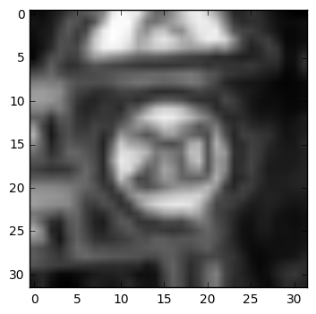

```python
def make_images_gray(images):
    gray_images = [cv2.cvtColor(img, cv2.COLOR_RGB2GRAY) for img in images]
    output = np.reshape(gray_images, (len(images), 32, 32, 1))
    return(output)

X_train_gray = make_images_gray(X_train)
#X_validation_gray = make_images_gray(X_validation)
X_test_gray = make_images_gray(X_test)

plt.imshow(X_train_gray[0, :, :, 0], cmap='gray')
```

```python
import cv2

def equalize_hist(img):
    img_yuv = cv2.cvtColor(img, cv2.COLOR_BGR2YUV)

    # equalize the histogram of the Y channel
    img_yuv[:,:,0] = cv2.equalizeHist(img_yuv[:,:,0])
    img_yuv[:,:,1] = cv2.equalizeHist(img_yuv[:,:,1])
    img_yuv[:,:,2] = cv2.equalizeHist(img_yuv[:,:,2])

    # convert the YUV image back to RGB format
    img_output = cv2.cvtColor(img_yuv, cv2.COLOR_YUV2BGR)

    return(img_output)

def equalize_hist_all(images):
    return(np.array([equalize_hist(img) for img in images]))

X_train_hist_eq = equalize_hist_all(X_train)
#X_validation_hist_eq = equalize_hist_all(X_validation)
X_test_hist_eq = equalize_hist_all(X_test)
```

```python
def equalize_hist_gray(img):
    # equalize the histogram of img
    img_histeq = cv2.equalizeHist(img)

    return(img_histeq)

def equalize_hist_gray_all(images):
    """
    Histogram equalizes all images in the input
    and returns it in an appropriate shape (?, 32, 32, 1)
    """
    hist_eq_images = np.array([equalize_hist_gray(img) for img in images])
    return(np.reshape(hist_eq_images, (len(images), 32, 32, 1)))

X_train_hist_eq_gray = equalize_hist_gray_all(make_images_gray(X_train))
#X_validation_hist_eq_gray = equalize_hist_gray_all(make_images_gray(X_validation))
X_test_hist_eq_gray = equalize_hist_gray_all(make_images_gray(X_test))
```

```python
# create a CLAHE object (Arguments are optional).
clahe = cv2.createCLAHE(clipLimit=2.0, tileGridSize=(8,8))

def clahe_gray(img):
    # equalize the histogram of img
    cl1 = clahe.apply(img)

    return(cl1)

def clahe_gray_all(images):
    clahed = np.array([clahe_gray(img) for img in images])
    output = np.reshape(clahed, (len(images), 32, 32, 1))
    return(output)

X_train_clahe_gray = clahe_gray_all(make_images_gray(X_train))
#X_validation_clahe_gray = clahe_gray_all(make_images_gray(X_validation))
X_test_clahe_gray = clahe_gray_all(make_images_gray(X_test))
```

### Question 2

*Describe how you set up the training, validation and testing data for your model. **Optional**: If you generated additional data, how did you generate the data? Why did you generate the data? What are the differences in the new dataset (with generated data) from the original dataset?*

**Answer:** Concerning the **optional** part: see *Question 1*.

The split in training and validation data was performed as follows: from reference [2], it became clear that the individual observations in the training set are **not independent**: sequences of 30 consecutive images come from a single video (i.e. image 0:30 are one video, 30:60 are the seconde video, etc.) capturing a single traffic sign. Thus the split into training and validation set was performed at the level of videos (otherwise the cross validation error would not be representative of the test set). 25% of these videos were resevered as validation set. The test set was taken as is from the data (here it was checked that consecutive images do not come from a single video).

The function to create the train/validation split calculates the number of videos, then splits the corresponding range into training and validation set using a 75/25 split.

### Question 3

*What does your final architecture look like? (Type of model, layers, sizes, connectivity, etc.) For reference on how to build a deep neural network using TensorFlow, see Deep Neural Network in TensorFlow from the classroom.*

**Answer:** The final architecture looks very similar to *LeNet*. The activation functions are always RELUs. It has the following layers:

1. Convolutional layer with a 5x5 filter, a stride of 1 and a depth of 16.
2. Max-Pooling layer of size 2x2 and a stride of 2.
3. Convolutional layer with a 5x5 filter, a stride of 1 and a depth of 32.
4. Max-Pooling layer of size 2x2 and a stride of2.
5. Fully connected layer with 200 hidden units and a dropout.
6. Fully connected layer with 200 hidden units and a dropout.

If the errors of the different neural networks are uncorrelated, then this bagging operation is expected to drastically reduce the error. The different preprocessing techniques in combination with the different learning parameters (and also the different initial weights) are supposed to make sure that the errors are not too correlated. The bagging worked reasonably well: the best cross validation result for a single architecture (since we pick the best, this probably overestimates the accuracy) suggested an accuracy of roughly 96.5%, the bagged network had 98.3%, i.e. a performance improvement of 1.8% and almost reducing the error rate by (relative) 50%.

```python
from tensorflow.contrib.layers import flatten

{'conv_filter_size_1': [5, 5, 3, 6],
                'conv_filter_size_2': [5, 5, 6, 16],
                'fc1_size': 300}



def train_single_dnn(x, params, MU, SIGMA, DROPOUT_RATE):
    """
    Trains a single deep neural network to be
    used in the formation of the MCDNN. The
    architecture of a single DNN is
    1. convolutional layer
    2. max pooling layer
    3. convolutional layer
    4. max pooling layer
    5. fully connected layer
    6. fully connected layer

    The parameters of layers can be set with the
    param argument.

    :param x: training data, a 32x32x3 image
    :params params: a dictionary containing all parameters needed for training
    """
    # First convolutional layer
    conv1_W = tf.Variable(tf.truncated_normal(params['conv_filter_size_1'], mean = MU, stddev = SIGMA), name='weight_1')
    conv1_b = tf.Variable(tf.zeros(params['conv_filter_size_1'][3]), name='bias_1')
    conv1 = tf.nn.conv2d(x, conv1_W, strides = [1, 1, 1, 1], padding='SAME') + conv1_b
    conv1 = tf.nn.relu(conv1)

    # Max pooling layer
    conv1 = tf.nn.max_pool(conv1, ksize = [1, 2, 2, 1], strides = [1, 2, 2, 1], padding = 'SAME')

    # Second convolutional layer
    conv2_W = tf.Variable(tf.truncated_normal(params['conv_filter_size_2'], mean = MU, stddev = SIGMA), name='weight_2')
    conv2_b = tf.Variable(tf.zeros(params['conv_filter_size_2'][3]), name='bias_2')
    conv2 = tf.nn.conv2d(conv1, conv2_W, strides = [1, 1, 1, 1], padding='SAME') + conv2_b
    conv2 = tf.nn.relu(conv2)

    # Max pooling layer
    conv2 = tf.nn.max_pool(conv2, ksize = [1, 2, 2, 1], strides = [1, 2, 2, 1], padding = 'SAME')

    # Flatten last convolutional layer
    fc0 = flatten(conv2)
    fc1_shape = int(fc0.get_shape()[1])

    # First fully connected layer
    fc1_W = tf.Variable(tf.truncated_normal(shape=(fc1_shape, params['fc1_size']), mean=MU, stddev=SIGMA), name ='weight_3')
    fc1_b = tf.Variable(tf.zeros(params['fc1_size']), name='bias_3')
    fc1 = tf.matmul(fc0, fc1_W) + fc1_b
    fc1 = tf.nn.relu(fc1)
    fc1 = tf.nn.dropout(fc1, keep_prob=DROPOUT_RATE)

    # Second fully connected layer
    fc2_W = tf.Variable(tf.truncated_normal(shape=(params['fc1_size'], params['fc2_size']), mean = MU, stddev = SIGMA), name='weight_4')
    fc2_b = tf.Variable(tf.zeros(params['fc2_size']), name='bias_4')
    fc2 = tf.matmul(fc1, fc2_W) + fc2_b
    fc2 = tf.nn.relu(fc2)
    fc2 = tf.nn.dropout(fc2, keep_prob=DROPOUT_RATE)

    # Third fully connected layer
    fc3_W = tf.Variable(tf.truncated_normal(shape=(params['fc2_size'], n_classes), mean = MU, stddev = SIGMA), name='weight_5')
    fc3_b = tf.Variable(tf.zeros((n_classes)), name='bias_5')
    logits = tf.matmul(fc2, fc3_W) + fc3_b

    return(logits)
```

### Question 4

*How did you train your model? (Type of optimizer, batch size, epochs, hyperparameters, etc.)*

**Answer:** As discussed in *Question* 3, different learning rates, batch sizes, standard deviations for the weight initialization and dropout rates were used in order to make the errors of the 25 models less correlated. A random search in hyperparameter space using cross-validation was used to find good sets of hyperparameters for single models: it was found that the learning rate should be between 0.0001 and 0.0005. The epochs parameter was held constant at 50: fewer epochs might have been possible to reduce computation time, but would not have increased accuracy. Cross-validation showed that the weights have to be initialized close to zero in order to have a well performing model, thus the standard deviation of the initialized weights (SIGMA) had to be close to zero (0.01 or 0.03). Dropout was introduced to reduce overfitting: dropout "turns off" units during the training process and thus leads to the network relying less on single neurons. Furthermore, it can also be seen as another way of model avering to reduce overfitting (effectively each dropout configuration, i.e. combination of deactivated neurons, correpsonds to a different network and all these different networks are averaged). The keep probability (here, falsely called DROPOUT_RATE) is varied as well. Cross validation revealed that a single DNN trains well across ranges of dropout.

As optimizer, I chose to stick with the *AdamOptimzer*. It would have been possible to also vary this "hyperparameter" in the process of building models to average.

The training was done on AWS with a g2.xlarge instance. The training and cross validation process was computationally intensive and this led to the not very deep convolutional layers.

```python
# Train the model
import tensorflow as tf

learning_params = [{'BATCH_SIZE': 128, 'EPOCHS': 50, 'LEARNING_RATE': 0.0004, 'MU': 0, 'SIGMA': 0.01, 'DROPOUT_RATE': 0.6},
                  {'BATCH_SIZE': 128, 'EPOCHS': 50, 'LEARNING_RATE': 0.0001, 'MU': 0, 'SIGMA': 0.01, 'DROPOUT_RATE': 0.33},
                  {'BATCH_SIZE': 32, 'EPOCHS': 50, 'LEARNING_RATE': 0.0005, 'MU': 0, 'SIGMA': 0.03, 'DROPOUT_RATE': 0.6},
                  {'BATCH_SIZE': 32, 'EPOCHS': 50, 'LEARNING_RATE': 0.0002, 'MU': 0, 'SIGMA': 0.03, 'DROPOUT_RATE': 0.9},
                  {'BATCH_SIZE': 256, 'EPOCHS': 50, 'LEARNING_RATE': 0.0004, 'MU': 0, 'SIGMA': 0.01, 'DROPOUT_RATE': 0.5}]

model_dict = [{'X_train': X_train, 'y_train': y_train,
               'save_file': 'model_color', 'num_colors': 3},
             {'X_train': X_train_gray, 'y_train': y_train,
               'save_file': 'model_gray', 'num_colors': 1},
             {'X_train': X_train_hist_eq, 'y_train': y_train,
               'save_file': 'model_histeq', 'num_colors': 3},
             {'X_train': X_train_hist_eq_gray, 'y_train': y_train,
               'save_file': 'model_histeq_gray', 'num_colors': 1},
             {'X_train': X_train_clahe_gray, 'y_train': y_train,
               'save_file': 'model_clahe', 'num_colors': 1}]

def training_pipeline(model_dict, learning_params):
    tf.reset_default_graph()

    LEARNING_RATE = learning_params['LEARNING_RATE']
    MU = learning_params['MU']
    SIGMA = learning_params['SIGMA']
    BATCH_SIZE = learning_params['BATCH_SIZE']
    EPOCHS = learning_params['EPOCHS']
    DROPOUT_RATE = learning_params['DROPOUT_RATE']
    num_colors = model_dict['num_colors']
    X_train = model_dict['X_train']
    y_train = model_dict['y_train']
    save_file = model_dict['save_file']

    params_arch = {'conv_filter_size_1': [5, 5, num_colors, 16],
                   'conv_filter_size_2': [5, 5, 16, 32],
                   'fc1_size': 200,
                   'fc2_size': 200}

    # Input-output vars
    x = tf.placeholder(tf.float32, (None, 32, 32, num_colors))
    y = tf.placeholder(tf.int32, (None))
    one_hot_y = tf.one_hot(y, n_classes)

    # Logits
    logits = train_single_dnn(x, params_arch, MU, SIGMA, DROPOUT_RATE)

    # Error function
    cross_entropy = tf.nn.softmax_cross_entropy_with_logits(logits, one_hot_y)
    loss_operation = tf.reduce_mean(cross_entropy)
    optimizer = tf.train.AdamOptimizer(learning_rate=LEARNING_RATE)
    training_operation = optimizer.minimize(loss_operation)

    # Evaluation
    correct_prediction = tf.equal(tf.argmax(logits, 1), tf.argmax(one_hot_y, 1))
    accuracy_operation = tf.reduce_mean(tf.cast(correct_prediction, tf.float32))

    # Saver
    saver = tf.train.Saver()

    with tf.Session() as sess:
        sess.run(tf.global_variables_initializer())
        num_examples = len(X_train)

        print("Training...")
        print()
        for i in range(EPOCHS):
            X_train, y_train = shuffle(X_train, y_train)
            for offset in range(0, num_examples, BATCH_SIZE):
                end = offset + BATCH_SIZE
                batch_x, batch_y = X_train[offset:end], y_train[offset:end]
                sess.run(training_operation, feed_dict={x: batch_x, y: batch_y})

        # Save the model
        saver.save(sess, save_file)
        print('Trained Model Saved.')
        sess.close()
    tf.reset_default_graph()


for model in model_dict:
    for k in range(len(learning_params)):
        print(learning_params[k])
        model_copy = model.copy()
        model_copy['save_file'] = model['save_file'] + '_' + str(k) + '.ckpt'
        training_pipeline(model_copy, learning_params[k])
```

```python
import tensorflow as tf

def prediction_pipeline(X_predict):
    """
    Performs predictions on the numpy array X_predict.
    Does all the preprocessing on X_predict, loads the models
    and takes the mean of the output.

    :param X_predict: numpy array of shape (?, 32, 32, 3)
    """
    model_dict = [{'X_predict': X_predict, 'save_file': './model_color', 'num_colors': 3},
                  {'X_predict': make_images_gray(X_predict), 'save_file': './model_gray', 'num_colors': 1},
                  {'X_predict': equalize_hist_all(X_predict), 'save_file': './model_histeq', 'num_colors': 3},
                  {'X_predict': equalize_hist_gray_all(make_images_gray(X_predict)), 'save_file': './model_histeq_gray', 'num_colors': 1},
                  {'X_predict': clahe_gray_all(make_images_gray(X_predict)), 'save_file': './model_clahe', 'num_colors': 1}]

    learning_params = [{'DROPOUT_RATE': 0.0},
                       {'DROPOUT_RATE': 0.33},
                       {'DROPOUT_RATE': 0.6},
                       {'DROPOUT_RATE': 0.9},
                       {'DROPOUT_RATE': 0.5}]



    output = np.zeros(shape = (X_predict.shape[0], n_classes))

    tf.reset_default_graph()

    def predict_single_dnn(model_dict):
        with tf.Session() as sess:

            params_arch = {'conv_filter_size_1': [5, 5, model_dict['num_colors'], 16],
                           'conv_filter_size_2': [5, 5, 16, 32],
                           'fc1_size': 200,
                           'fc2_size': 200}

            # Input-output vars
            x = tf.placeholder(tf.float32, (None, 32, 32, model_dict['num_colors']))
            y = tf.placeholder(tf.int32, (None))
            one_hot_y = tf.one_hot(y, n_classes)

            # Logits
            logits = train_single_dnn(x, params_arch, 0, 0, DROPOUT_RATE)

            all_vars = tf.trainable_variables()
            loader = tf.train.Saver()
            loader.restore(sess, model_dict['save_file'])

            #sess.run(tf.global_variables_initializer())
            output = sess.run(logits, feed_dict={x: model_dict['X_predict']})

            return(output)

    for model in model_dict:
        for k in range(5):
            DROPOUT_RATE = 1.0
            model_copy = model.copy()
            model_copy['save_file'] = model_copy['save_file'] + '_' + str(k) + '.ckpt'
            tf.reset_default_graph()
            output += predict_single_dnn(model_copy)

    output = output / len(model_dict)

    return(output)

predicted = prediction_pipeline(X_test)
```

```python
def calculate_accuracy(predicted, actual):
    """
    Calculates the accuracy of the predictions
    versus the actual values

    :param predicted: numpy array of shape (?, n_classes)
    :param actual: numpy array of (?) with distinct entries 0:n_classes
    """
    prediction = predicted.argmax(axis=1)
    indicator = np.equal(prediction, actual)
    return(indicator.mean())

calculate_accuracy(predicted, y_test)
```

```
0.9840855106888361
```

### Question 5

*What approach did you take in coming up with a solution to this problem? It may have been a process of trial and error, in which case, outline the steps you took to get to the final solution and why you chose those steps. Perhaps your solution involved an already well known implementation or architecture. In this case, discuss why you think this is suitable for the current problem.*

**Answer:** The main goal was to reproduce the results of Ref [2] (simply because these are extremly strong results).

My main approach was to first split the training set further into a training set and a validation set. This splitting had to be performed at the level of **videos**, not at the level of individual images. Otherwise, this would have led to highly optimistic accuracy estimates, since the test set was from distinct videos, not distinct images. See the appendix for the code.

The architecture in Ref [2] is very similar to the LeNet architecture, but lacks the last fully connected layer. It was decided, to try the training process both with and without this layer. The cross validation results suggested that this layer was benefical. From a bagging perspective, it would actually have been preferable to even keep different network architectures, but due to a lack of time, it was decided to not pursue this approach further.

The next step was to find reasonable sets of hyperparameters (cross validation results for a single CNN and a given set of hyperparameters can be found in the files **SDNN_x.csv**): there are hyperparameter settings for which the cross validation results are not better than randomly guessing the class of the image. These setting would not have been very beneficial to the bagged model. Randomly searching over a limited set of hyperparameters (the limits were found by trial and error) is computationally less intensive than doing a grid search, but leads to similiar results [3]. The cross validation was performed for each differently preprocessed copy of the input data and the results were stored in csv files. Finally, a well performing set of five combinations of hyperparameters were chosen for the final training process.

The results are very promising with an accuracy rate of 98.3%, but they are nevertheless worse then in Ref [2]. One possible reason is that the images in [2] had a higher resolution of 48x48. This seems very plausible because in [2], the researchers were able to train a single DNN to an accuracy rate of 98.5%.

Also, due to a lack of time (or knowledge) it was not possible to perform the *imadjust* preprocessing. This might have led to an additional incremental improvement.

There are various possibilities for improving the performance:

1. Perform more bagging by using different architectures
2. Add inception layers
3. Make the network deeper

## Step 3: Test a Model on New Images

Take several pictures of traffic signs that you find on the web or around you (at least five), and run them through your classifier on your computer to produce example results. The classifier might not recognize some local signs but it could prove interesting nonetheless.

You may find `signnames.csv` useful as it contains mappings from the class id (integer) to the actual sign name.

### Implementation

Use the code cell (or multiple code cells, if necessary) to implement the first step of your project. Once you have completed your implementation and are satisfied with the results, be sure to thoroughly answer the questions that follow.

### Question 6

*Choose five candidate images of traffic signs and provide them in the report. Are there any particular qualities of the image(s) that might make classification difficult? It could be helpful to plot the images in the notebook.*

**Answer:**

```python
def read_image(img_path):
    img = cv2.imread(img_path)
    RGB_img = cv2.cvtColor(img, cv2.COLOR_BGR2RGB)

    return(RGB_img)
```

#### Example 1

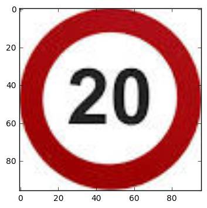

```python
plt.imshow(read_image('./new_signs/example1.jpeg'))
```

[figure not shown]

```python
plt.imshow(cv2.resize(read_image('./new_signs/example1.jpeg'), (32, 32)))
```

This image is not taken from a camera. This makes it non-representative with respect to the training sample, which should make it more difficult to recognise. On the other hand, it is extremly easy for a human.

#### Example 2

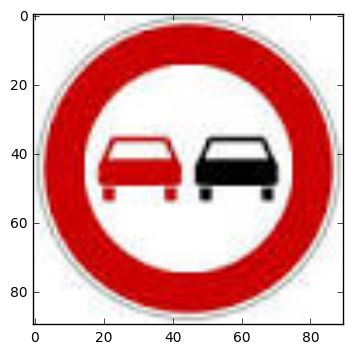

```python
plt.imshow(read_image('./new_signs/example2.jpeg'))
```

[figure not shown]

```python
plt.imshow(cv2.resize(read_image('./new_signs/example2.jpeg'), (32, 32)))
```

Same situation as with example 1.

#### Example 3

[figure not shown]

```python
plt.imshow(read_image('./new_signs/example3.jpg'))
```

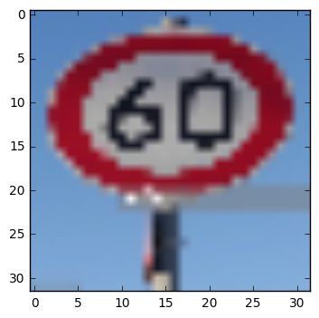

```python
plt.imshow(cv2.resize(read_image('./new_signs/example3.jpg'), (32, 32)))
```

The only difficult part in this example might be the angle and the additional gray area ('gettyimages')

#### Example 4

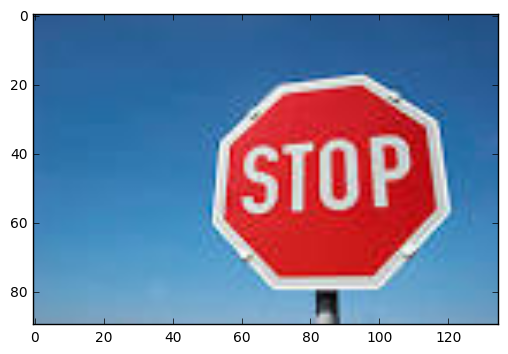

```python
plt.imshow(read_image('./new_signs/example4.jpeg'))
```

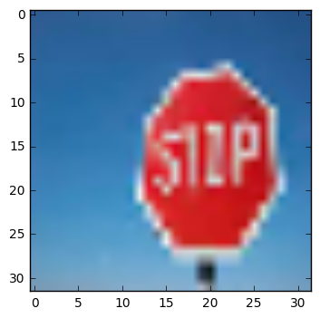

```python
plt.imshow(cv2.resize(read_image('./new_signs/example4.jpeg'), (32, 32)))
```

This looks fairly straightforward.

#### Example 5

[figure not shown]

```python
plt.imshow(read_image('./new_signs/example5.jpeg'))
```

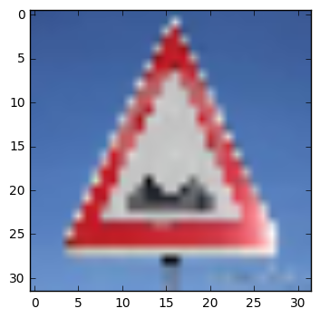

```python
plt.imshow(cv2.resize(read_image('./new_signs/example5.jpeg'), (32, 32)))
```

This does not look too difficult either.

### Question 7

*Is your model able to perform equally well on captured pictures when compared to testing on the dataset? The simplest way to do this check the accuracy of the predictions. For example, if the model predicted 1 out of 5 signs correctly, it's 20% accurate.*

**NOTE:** You could check the accuracy manually by using `signnames.csv` (same directory). This file has a mapping from the class id (0-42) to the corresponding sign name. So, you could take the class id the model outputs, lookup the name in `signnames.csv` and see if it matches the sign from the image.

**Answer:**

```python
images = ['./new_signs/example1.jpeg',
         './new_signs/example2.jpeg',
         './new_signs/example3.jpg',
         './new_signs/example4.jpeg',
         './new_signs/example5.jpeg']

def read_image_small(img_path):
    img = cv2.imread(img_path)
    RGB_img = cv2.cvtColor(img, cv2.COLOR_BGR2RGB)
    small_img = cv2.resize(RGB_img, (32, 32))

    return(small_img)

def parse_images(images):
    return(np.array([read_image_small(img) for img in images]))

logits = prediction_pipeline(parse_images(images))
```

```python
right_signs = ['Speed limit (20km/h)', 'No passing', 'Speed limit (60km/h)', 'Stop', 'Bumpy road']
predictions = np.argmax(logits, axis=1)
predictions = pd.DataFrame(predictions, columns=['Classid'])
predictions['image_number'] = range(1, 6)
predictions = predictions.set_index('image_number')
predictions = predictions.join(y_train_labels, on = 'Classid', how = 'inner')
predictions['right_sign'] = right_signs
predictions.sort_index()
```

| image_number | Classid | ClassId | SignName | right_sign |
| --- | --- | --- | --- | --- |
| 1 | 16 | 16 | Vechiles over 3.5 metric tons prohibited | Speed limit (20km/h) |
| 2 | 9 | 9 | No passing | No passing |
| 3 | 12 | 12 | Priority road | Speed limit (60km/h) |
| 4 | 14 | 14 | Stop | Stop |
| 5 | 22 | 22 | Bumpy road | Bumpy road |

### Question 8

*Use the model's softmax probabilities to visualize the **certainty** of its predictions, [`tf.nn.top_k`](https://www.tensorflow.org/versions/r0.12/api_docs/python/nn.html#top_k) could prove helpful here. Which predictions is the model certain of? Uncertain? If the model was incorrect in its initial prediction, does the correct prediction appear in the top k? (k should be 5 at most)*

`tf.nn.top_k` will return the values and indices (class ids) of the top k predictions. So if k=3, for each sign, it'll return the 3 largest probabilities (out of a possible 43) and the correspoding class ids.

Take this numpy array as an example:

```
# (5, 6) array
a = np.array([[ 0.24879643,  0.07032244,  0.12641572,  0.34763842,  0.07893497,
         0.12789202],
       [ 0.28086119,  0.27569815,  0.08594638,  0.0178669 ,  0.18063401,
         0.15899337],
       [ 0.26076848,  0.23664738,  0.08020603,  0.07001922,  0.1134371 ,
         0.23892179],
       [ 0.11943333,  0.29198961,  0.02605103,  0.26234032,  0.1351348 ,
         0.16505091],
       [ 0.09561176,  0.34396535,  0.0643941 ,  0.16240774,  0.24206137,
         0.09155967]])
```

Running it through `sess.run(tf.nn.top_k(tf.constant(a), k=3))` produces:

```
TopKV2(values=array([[ 0.34763842,  0.24879643,  0.12789202],
       [ 0.28086119,  0.27569815,  0.18063401],
       [ 0.26076848,  0.23892179,  0.23664738],
       [ 0.29198961,  0.26234032,  0.16505091],
       [ 0.34396535,  0.24206137,  0.16240774]]), indices=array([[3, 0, 5],
       [0, 1, 4],
       [0, 5, 1],
       [1, 3, 5],
       [1, 4, 3]], dtype=int32))
```

Looking just at the first row we get `[ 0.34763842, 0.24879643, 0.12789202]`, you can confirm these are the 3 largest probabilities in `a`. You'll also notice `[3, 0, 5]` are the corresponding indices.

```python
top_5 = pd.DataFrame(np.argsort(-logits, axis=1)[:, :5])
top_5['image_number'] = range(1, 6)
top_5['right_sign'] = right_signs
top_5 = pd.melt(top_5, id_vars = ['image_number'], value_vars = [0, 1, 2, 3, 4], value_name='Classid')
top_5 = top_5.rename(columns={'variable': 'Rank'})
top_5 = top_5.join(y_train_labels, on = 'Classid', how = 'inner')
top_5 = top_5[['image_number', 'Rank', 'SignName']].sort_values(['image_number', 'Rank'])

top_5_pivot = top_5.pivot(index='image_number', columns='Rank')
top_5_pivot['right_sign'] = right_signs
top_5_pivot
```

| Rank image_number | SignName 0 | SignName 1 | SignName 2 | SignName 3 | SignName 4 | right_sign |
| --- | --- | --- | --- | --- | --- | --- |
| 1 | Vechiles over 3.5 metric tons prohibited | Speed limit (80km/h) | Speed limit (30km/h) | End of speed limit (80km/h) | Speed limit (20km/h) | Speed limit (20km/h) |
| 2 | No passing | End of no passing | No passing for vechiles over 3.5 metric tons | Vechiles over 3.5 metric tons prohibited | Slippery road | No passing |
| 3 | Priority road | No passing | Yield | No entry | No passing for vechiles over 3.5 metric tons | Speed limit (60km/h) |
| 4 | Stop | No entry | Road work | Yield | Priority road | Stop |
| 5 | Bumpy road | Bicycles crossing | Traffic signals | Road work | Dangerous curve to the right | Bumpy road |

**Answer:** The predicted classes and the right classes can be seen in the table above. We see that in the first example, the correct answer (Speed limit 20 km/h) is in the top 5. For the other incorrect example (image_number == 3), the correct answer (speed limit 60) is not in the top 5.

The table below shows the certainty of the predictions: the neural net is **very certain** in each case (basically it predicts a probability of one in each case), which is a sign of overfitting. This could have been prevented by reducing the number of epochs, though that would not have helped to increase the accuracy.

```python
probs = np.exp(logits) / np.sum(np.exp(logits), axis=1)[:, None]
top_5_scores = pd.DataFrame(-np.sort(-probs, axis=1)[:, :5])
top_5_scores['image_number'] = range(1, 6)
top_5_scores = pd.melt(top_5_scores, id_vars = ['image_number'], value_vars = [0, 1, 2, 3, 4], value_name='Score')
top_5_scores = top_5_scores.rename(columns={'variable': 'Rank'})
top_5_scores.pivot(index='image_number', columns='Rank')
```

| Rank image_number | Score 0 | Score 1 | Score 2 | Score 3 | Score 4 |
| --- | --- | --- | --- | --- | --- |
| 1 | 0.99887 | 1.095480e-03 | 3.477451e-05 | 2.535362e-10 | 1.117832e-10 |
| 2 | 1.00000 | 7.249855e-76 | 3.785788e-82 | 6.917656e-98 | 9.559003e-115 |
| 3 | 0.99729 | 2.709646e-03 | 3.611178e-15 | 2.139020e-18 | 2.193087e-26 |
| 4 | 1.00000 | 7.986121e-40 | 4.042703e-47 | 3.491635e-49 | 9.688982e-50 |
| 5 | 1.00000 | 1.620379e-89 | 1.638827e-111 | 6.899074e-115 | 1.142128e-121 |

## References

[1] Pierre Sermanet and Yann LeCun; Traffic Sign Recognition with Multi-Scale Convolutional Networks;

[2] Dan Cireşan, Ueli Meier, Jonathan Masci, Jürgen Schmidhuber; Multi-column deep neural network for traffic sign classification; Neural Networks 32 (2012) 333–338

[3] James Bergstra, Yoshua Bengio; Random Search for Hyper-Parameter Optimization; Journal of Machine Learning Research 13 (2012) 281-305

# Appendix

## Code for Cross Valdiation

```python
# Load pickled data
import pickle
from sklearn.model_selection import train_test_split
from sklearn.utils import shuffle
import numpy as np

def split_train_cv(X_train, y_train):
    train_length = X_train.shape[0] / 30
    train_ind, cv_ind = train_test_split(range(int(train_length)), test_size=0.25, random_state=0)

    train_ind = np.array(train_ind, dtype=int) * 30
    cv_ind = np.array(cv_ind, dtype=int) * 30

    training_set = np.reshape(np.array([X_train[ind:ind + 30, :, :, :] for ind in train_ind]), (-1, 32, 32, 3))
    cv_set = np.reshape(np.array([X_train[ind:ind + 30, :, :, :] for ind in cv_ind]), (-1, 32, 32, 3))

    training_set_y = np.reshape(np.array([y_train[ind:ind + 30:] for ind in train_ind]), -1)
    cv_set_y = np.reshape(np.array([y_train[ind:ind + 30:] for ind in cv_ind]), -1)

    return(training_set, training_set_y, cv_set, cv_set_y)

training_file = "./traffic-signs-data/train.p"
testing_file = "./traffic-signs-data/test.p"

with open(training_file, mode='rb') as f:
    train = pickle.load(f)
with open(testing_file, mode='rb') as f:
    test = pickle.load(f)

X_train, y_train = train['features'], train['labels']
X_test, y_test = test['features'], test['labels']

# Split training set further into training set and validation set

X_train, y_train, X_validation, y_validation = split_train_cv(X_train, y_train)

assert(len(X_train) == len(y_train))
assert(len(X_validation) == len(y_validation))
assert(len(X_test) == len(y_test))

print()
print("Image Shape: {}".format(X_train[0].shape))
print()
print("Training Set:   {} samples".format(len(X_train)))
print("Validation Set: {} samples".format(len(X_validation)))
print("Test Set:       {} samples".format(len(X_test)))
```

```python
def sample_learning_params(learning_params_grid):
    sample_params = {}
    for key in learning_params_grid:
        random_index = np.random.randint(low = 0, high = len(learning_params_grid[key]))
        sample_params[key] = learning_params_grid[key][random_index]

    return(sample_params)
```

```python
import tensorflow as tf
from tensorflow.contrib.layers import flatten
import os.path
file_path = './SDNN_color.csv'
num_colors = 3

n_iterations = 30

params_learn = {'LEARNING_RATE': [0.0001, 0.0002, 0.0003, 0.0004, 0.0005],
               'BATCH_SIZE': [16, 32, 64, 128, 256],
               'MU': [0],
               'SIGMA': [0, 0.01, 0.03],
               'EPOCHS': [50],
               'DROPOUT_RATE': [0.001, 0.25, 0.33, 0.5, 0.6, 0.75, 0.9]}

params_arch = [{'conv_filter_size_1': [5, 5, num_colors, 32],
                'conv_filter_size_2': [5, 5, 32, 64],
                'fc1_size': 300,
                'fc2_size': 200},
               {'conv_filter_size_1': [5, 5, 1, 6],
                'conv_filter_size_2': [5, 5, 6, 16],
                'fc1_size': 300},
               {'conv_filter_size_1': [5, 5, 3, 16],
                'conv_filter_size_2': [5, 5, 16, 32],
                'fc1_size': 80},
               {'conv_filter_size_1': [7, 7, 3, 8],
                'conv_filter_size_2': [7, 7, 8, 6],
                'fc1_size': 120},
               {'conv_filter_size_1': [5, 5, 3, 32],
                'conv_filter_size_2': [5, 5, 32, 16],
                'fc1_size': 80}]

def training_pipeline(X_train, y_train, X_validation, y_validation, learning_params):
    LEARNING_RATE = learning_params['LEARNING_RATE']
    MU = learning_params['MU']
    SIGMA = learning_params['SIGMA']
    BATCH_SIZE = learning_params['BATCH_SIZE']
    EPOCHS = learning_params['EPOCHS']
    DROPOUT_RATE = learning_params['DROPOUT_RATE']

    # Input-output vars
    x = tf.placeholder(tf.float32, (None, 32, 32, num_colors))
    y = tf.placeholder(tf.int32, (None))
    one_hot_y = tf.one_hot(y, n_classes)

    # Logits
    logits = train_single_dnn(x, params_arch[0], MU, SIGMA, DROPOUT_RATE)

    # Error function
    cross_entropy = tf.nn.softmax_cross_entropy_with_logits(logits, one_hot_y)
    loss_operation = tf.reduce_mean(cross_entropy)
    optimizer = tf.train.AdamOptimizer(learning_rate=LEARNING_RATE)
    training_operation = optimizer.minimize(loss_operation)

    # Evaluation
    correct_prediction = tf.equal(tf.argmax(logits, 1), tf.argmax(one_hot_y, 1))
    accuracy_operation = tf.reduce_mean(tf.cast(correct_prediction, tf.float32))

    def evaluate(X_data, y_data, sess):
        num_examples = len(X_data)
        total_accuracy = 0
        for offset in range(0, num_examples, BATCH_SIZE):
            batch_x, batch_y = X_data[offset:offset+BATCH_SIZE], y_data[offset:offset+BATCH_SIZE]
            accuracy = sess.run(accuracy_operation, feed_dict={x: batch_x, y: batch_y})
            total_accuracy += (accuracy * len(batch_x))
        return total_accuracy / num_examples

    with tf.Session() as sess:
        sess.run(tf.global_variables_initializer())
        num_examples = len(X_train)

        print("Training...")
        print()
        for i in range(EPOCHS):
            X_train, y_train = shuffle(X_train, y_train)
            for offset in range(0, num_examples, BATCH_SIZE):
                end = offset + BATCH_SIZE
                batch_x, batch_y = X_train[offset:end], y_train[offset:end]
                sess.run(training_operation, feed_dict={x: batch_x, y: batch_y})

            validation_accuracy = evaluate(X_validation, y_validation, sess)
            print("EPOCH {} ...".format(i+1))
            print("Validation Accuracy = {:.3f}".format(validation_accuracy))
            print()

    learning_params['ACCURACY'] = validation_accuracy
    return(learning_params)



def tune_parameter_random_search(X_train, y_train, X_validation, y_validation, params_learn, n_iterations):
    results = []
    for k in range(n_iterations):
        params = sample_learning_params(params_learn)
        print("Learning parameters:")
        print(params)
        results_params = training_pipeline(X_train, y_train, X_validation, y_validation, params)
        if os.path.isfile(file_path):
            pd.DataFrame(results_params, index=[0]).to_csv(file_path, mode='a', header = False)
        else:
            pd.DataFrame(results_params, index=[0]).to_csv(file_path, index = False)

        results.append(results_params)

    return(results)

cv_results = tune_parameter_random_search(X_train, y_train, X_validation, y_validation,
                                          params_learn, n_iterations)
```